# Part II - Ford GoBike Trip lengths over weekdays, Usertype, gender

## by Muhammad almutiri

## Investigation Overview

> in this investigation, i looked at how the trip lengths could change in regards to user type, genders, and on which weekday the trips were taken, and how all of those elements could effect said trip lengths

## Dataset Overview

> ford go bike dataset which is dataset that includes information about individual rides made in a bike-sharing system covering the greater San Francisco Bay area. the data consists of 183412 instances and 16 features, out of those 16 features we got 2 of the type int, 7 floats , 2 datetime and 5 objects (9 numerical , 2 dates , 5 objects)

## 1. distribution of trip durations

> trip lengths range from 60 seconds (1 minute) up to 85444 seconds (~ 24 hours), i will be ploting it on logarithmic scale it takes unimodal Distribution shape. with most trips taking place between 500 to 700 seconds

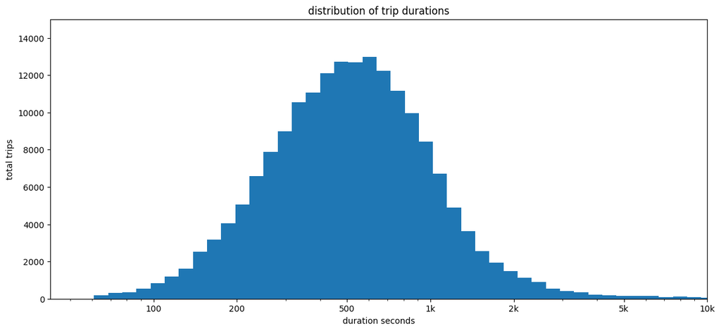

## 2. distribution user type over the number trips

> users were split into two groups subscribers and customers the larger of which is the subscribers with 160k, while customers are less than 40k

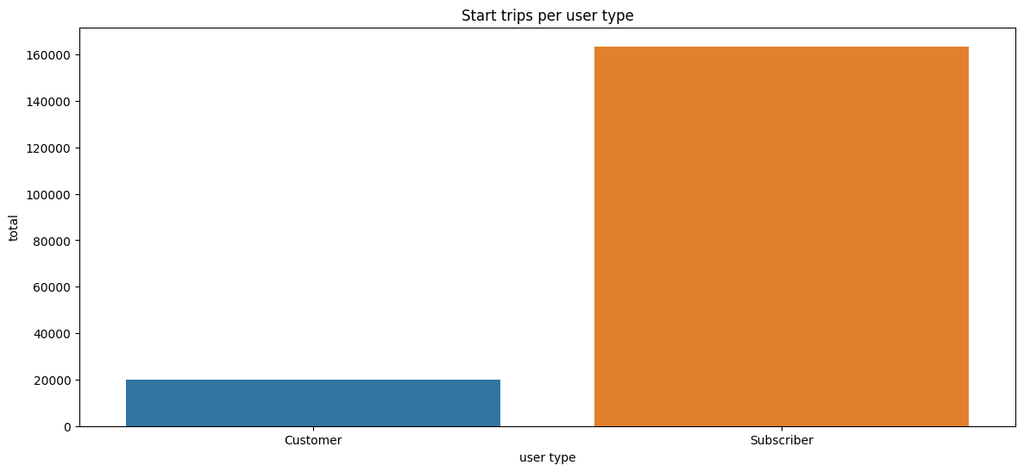

## 3. user type distribution over trips duration

> Ploting the user type with repsepect to trip durations, allthough we have seen that subscribers are more than customers we can see from the plot that customers on avg have longer trips

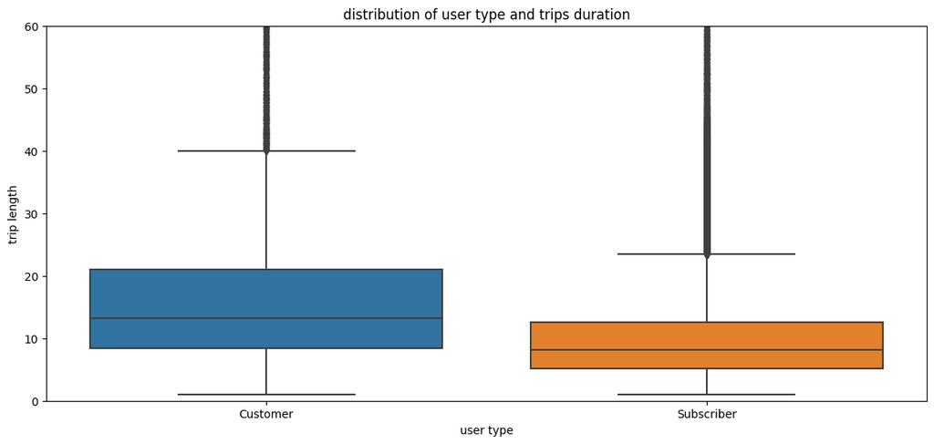

## 4. distribution of user type over weekdays

> subscribers take more trips on all week days.

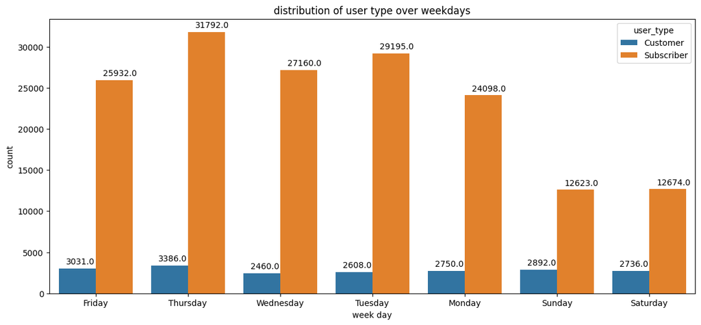

## 5. user type distribution over trips duration and weekdays

> customers on avg take longer trips on all week days with spikes on weekends, while subscribers have a lower but consistent avg on all days with no spikes.

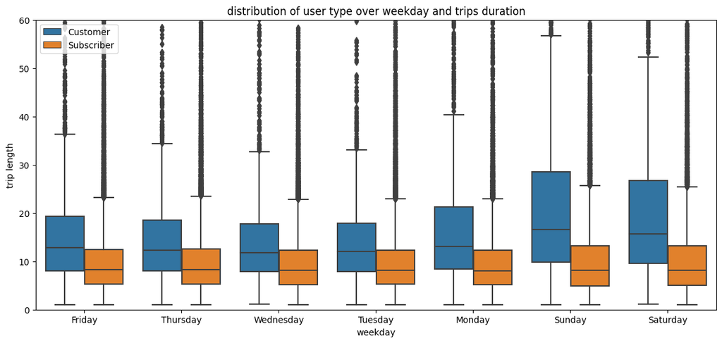

## 6. gender and user type distribution over trips duration

> customers on all genders have longer trips than subscribers

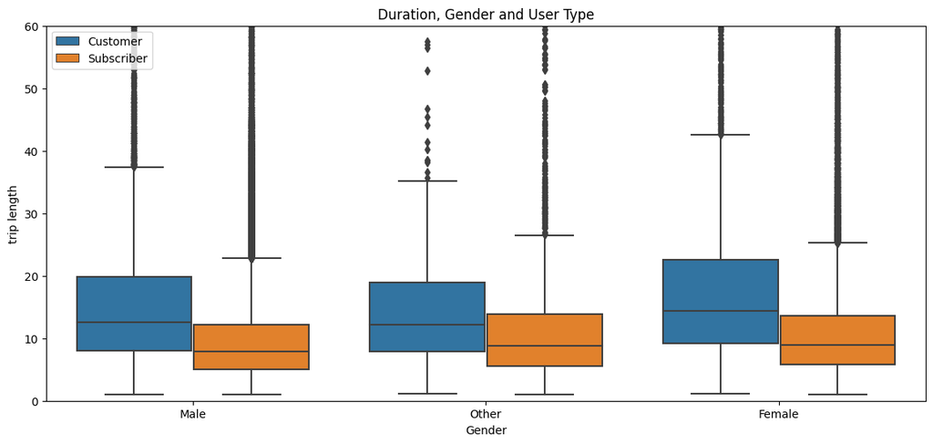